# Correction TD2

## Deuxième méthode

Ce qu’on va faire maintenant est de simuler beaucoup des points dans le carré entre 0 et 1. L’aire qu’on souhaite calculer sera la proportion des points qui est dans la région bleue de la figure suivante divisée par l’aire de rectange rouge (donc 1) :

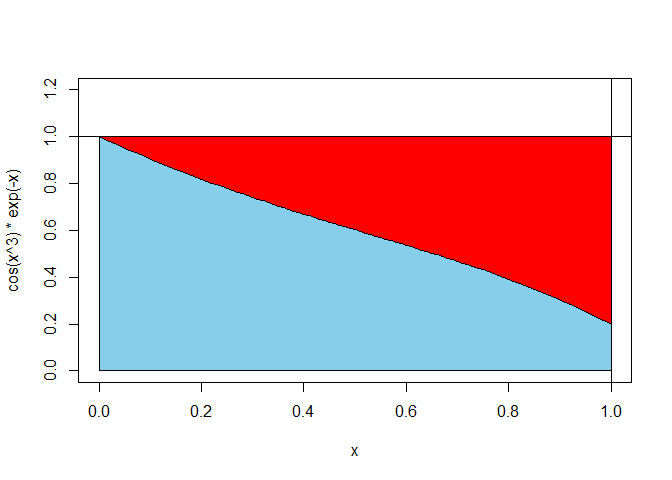

```r
N = 10000
x = runif(N,0,1)
y = runif(N,0,1)
s = cos(x^3)*exp(-x) > y # ceci va retourner TRUE ou FALSE
I1 = sum(s)/N
cat("valeur approchée de I_1 = ", I1)
```

```
## valeur approchée de I_1 =  0.5908
```

Remarque: A savoir qu’ici on considère pour chaque point généré on a une épreuve de Bernoulli qu’on peut appeler $S$ qui vaut 1 si le point est en dessous de la courve et 0 sinon. On va se baser sur ce principe dans les exercices suivants.

# Exercice 5

## Question 1

Ici on génére des points sur le carré [-1,1] x [-1,1]. Nous souhaitons calculer $E(1_{X\in D})$. Appelons $S = 1_{X\in D}$ une variable aléatoire (qui vaut 1 si le point est dans le disque et 0 sinon). A savoir que $S$ est une variable qui suit la loi de Bernoulli de paramètre $p$. Donc $E(S)=p$. On va générer selon la loi uniforme des points dans le carré et estimer $p$ par la proportion des points à l’intérieur du disque.

Remarques:

- L’équation du cercle est $x^2+y^2=1$ et son aire est $\pi R^2 = \pi$.
- $p$ vaut théoriquement $\pi/4$. L’aire de disque divisée par l’aire de carré.

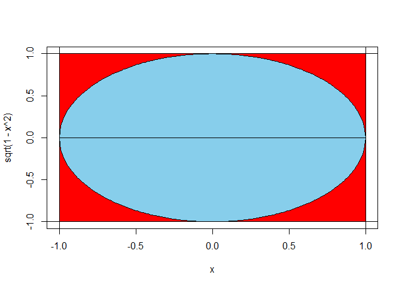

```r
n=10000
x=runif(n,-1,1)
y=runif(n,-1,1)
E = sum(x^2+y^2 < 1)/n
cat("valeur approchée de E = ", E)
```

```
## valeur approchée de E =  0.7836
```

Remarque: d’autre part: $\pi/4 =$ 0.7853982.

## Question 2

On souhaite approximer $V(S)$ qui vaut théoriquement $p(1-p)=\frac{\pi}{4}(1-\frac{\pi}{4})$=0.1685479.

A remarquer aussi que $\frac{1}{2}V(S_1-S_2) = \frac{1}{2} E[(S_1-S_2)^2]$.

Donc

```r
n=1000
# simulation de S1
x1 = runif(1000,-1,1)
y1 = runif(1000,-1,1)
s1 = x1^2 + y1^2 <= 1
# simulation de S2
x2 = runif(1000,-1,1)
y2 = runif(1000,-1,1)
s2 = x2^2 + y2^2 <= 1

E = 1/2 *  sum((s1 - s2)^2)/n
cat("valeur approchée de E = ", E)
```

```
## valeur approchée de E =  0.1765
```

## Question 3

[figure not shown]